# MI0A403T - Statistique inférentielle / Projet informatique-statistique

Les deux zones montrent une grande variabilité d’année en année, mais on remarque que la Zone Basse affiche constamment des superficies brûlées plus importantes et des extrêmes plus prononcés que la Zone Haute.

Cela confirme l’interprétation du diagramme en boîte précédent, où les incendies en altitude basse étaient plus répandus et plus variables.

On observe une correspondance entre les deux régions, particulièrement aux alentours de 2016-2017 où les deux présentent des pics.

On peut en déduire que cela découle de facteurs climatiques et environnementaux partagés.

Les segments verticaux s’étendent bien plus haut que bas, ce qui nous autorise à conclure qu’il s’agit d’une distribution asymétrique vers la droite.

La concordance des deux zones, approximativement entre 2016 et 2017,pourrait être attribuée à des conditions météorologiques telles qu’une sécheresse prolongée ou des températures élevées qui facilitent la diffusion des incendies.

La région basse présentant systématiquement des superficies plus étendues est vulnérable à ces circonstances en raison d’une densité de végétation plus importante ou d’une accessibilité humaine accrue.

La Zone Haute présente généralement des zones brûlées plus réduites, sans doute en raison de conditions moins propices à la propagation telles que la présence réduite de combustible, des températures plus fraîches et des sols rocailleux.

Cependant, le record de 2016 indique que des phénomènes rares comme les vents violents ou les éclairs peuvent causer des incendies conséquents même à haute altitude.

Concernant les tendances récentes, la baisse des zones incendiées après 2020 dans les deux régions pourrait témoigner d’initiatives de prévention telles que la gestion forestière,la lutte anti-incendie ou encore des modifications climatiques comme une augmentation de la fréquence des précipitations. 4- **Les Catégories des Incendies par zone d’altitude:**

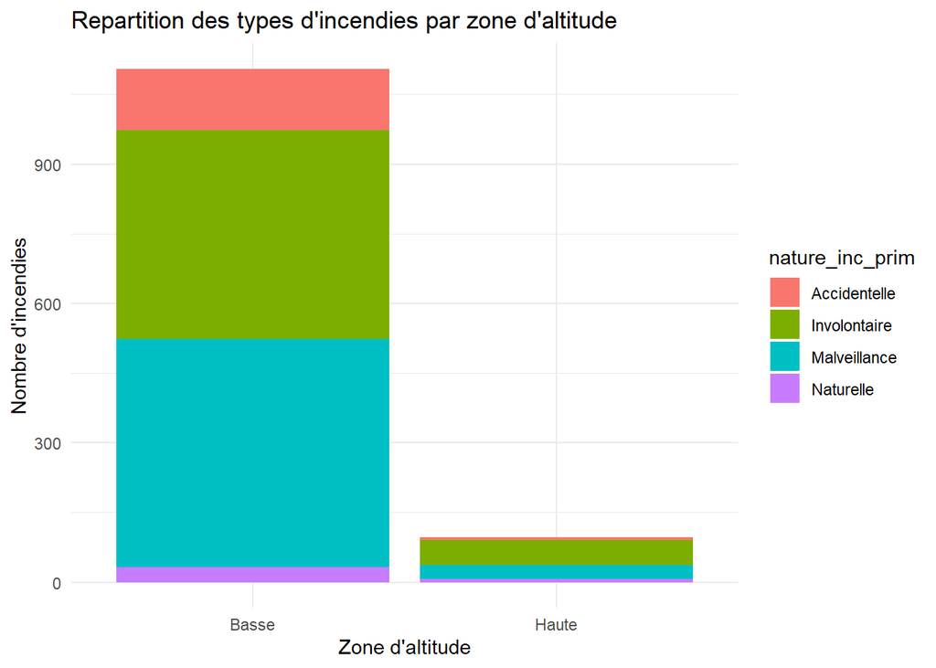

```r
incendiesregions <- read.csv("../Exports/export_incendiesregions.csv")
ggplot(incendiesregions, aes(x = altitude_zone, fill = nature_inc_prim)) +
  geom_bar(position = "stack") +
  labs(title = "Repartition des types d'incendies par zone d'altitude",
       x = "Zone d'altitude", y = "Nombre d'incendies") +
  theme_minimal()
```

1- **Analyse Informatique:**

On a d’abord chargé les données dans une variable qui contient les données sous la forme d’un tableau dataframe provenant du fichier CSV contenant toutes les informations requises.

Par la suite, on emploie la méthode **gplot** qui est prédéfinie dans la bibliothèque **ggplot2**. Pour générer le graphique basé sur les informations du fichier CSV, elle nécessite deux paramètres clés : le premier est la variable qui contient les données et l’autre est l’**aes aesthetics** où l’on spécifie l’axe des x qui illustrera les différentes zones d’altitude. Nous activons également l’option **fill** pour permettre une coloration en fonction du type d’incendie indiqué dans la variable **nature_inc-_prim**.

Ensuite, nous ajoutons les barres empilées au graphique en utilisant la méthode prédéfinie **geom_bar**. Nous précisons que la position sera **stack**, ce qui signifie que les barres seront superposées et chaque couleur représentera une catégorie distincte de **nature_insc_prim**. La hauteur totale de la barre indiquera le nombre total d’incendies dans chaque zone d’altitude.

Si l’on souhaite se baser sur la proportion des différents types d’incendies plutôt que sur les valeurs absolues, on pourrait recourir à la valeur **fill**. Cela nous aidera à normaliser les barres afin qu’elles aient toutes la même hauteur, illustrant ainsi la proportion de chaque type d’incendie.

**Nous allons insérer le graphique joint, cependant, nous ne procéderons pas à l’analyse de la position fill, mais plutôt à celle de la position stack**

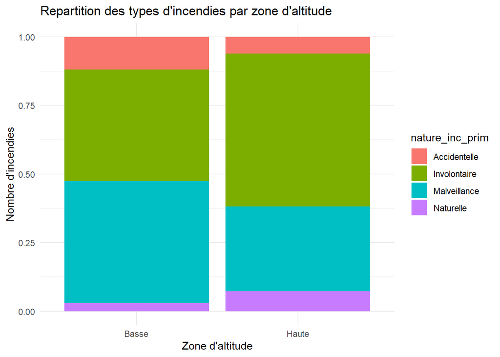

```r
incendiesregions <- read.csv("../Exports/export_incendiesregions.csv")
ggplot(incendiesregions, aes(x = altitude_zone, fill = nature_inc_prim)) +
  geom_bar(position = "fill") +
  labs(title = "Repartition des types d'incendies par zone d'altitude",
       x = "Zone d'altitude", y = "Nombre d'incendies") +
  theme_minimal()
```

Par la suite, nous intégrons les étiquettes et le titre en employant la méthode prédéfinie **labs()**, en précisant les deux axes x et y ainsi que le titre principal de notre graphique.

Et finalement, pour l’application d’un thème moderne au style épuré, nous utilisons la méthode prédéfinie **theme_minimal()**.

2- **Analyse Statistique:**

En guise d’introduction, voici un histogramme empilé qui illustre le total des incendies dans deux zones distinctes, Basse et Haute.

Dans cette étude, on considère que la basse altitude est inférieure à 1000 mètres et la haute altitude, supérieure à 1000 mètres.

L’axe horizontal (X) illustre les zones d’altitudes, tandis que l’axe vertical (Y) représente le nombre d’incendies, allant approximativement de 0 à 1200.

Pour les types d’incendies, nous avons quatre catégories : accidentel représenté en rouge, involontaire en vert, malveillance en cyan et naturel en violet.

**Dans la Zone Basse la repartittion est estimee en :**

On fait une estimation d’environ **1200 incendies** dans **la région basse**.

Pour déterminer si la distribution des types d’incendies est influencée par l’altitude de la zone, nous ferons appel au test d’indépendance du Chi2.

Ce tableau a été élaboré sur la base d’estimations des données.

[output not shown]

On établit l’**Hypothèse Nulle (H0)** selon laquelle la distribution des types d’incendies est indépendante de la zone d’altitude.

**Hypothèse Alternative (H1)**La distribution est influencée par la zone d’altitude.

Nous allons effectuer le calcul en employant le langage R.

```r
observed <- matrix(c(200, 400, 500, 50,  # Zone Basse
                     30, 100, 50, 10),   # Zone Haute
                   nrow = 4, byrow = FALSE)
rownames(observed) <- c("Accidentelle", "Involontaire", "Malveillance", "Naturelle")
colnames(observed) <- c("Basse", "Haute")

print("Fréquences observées :")
```

```
## [1] "Fréquences observées :"
```

```r
print(observed)
```

```
##              Basse Haute
## Accidentelle   200    30
## Involontaire   400   100
## Malveillance   500    50
## Naturelle       50    10
```

```r
row_totals <- rowSums(observed)
col_totals <- colSums(observed)
grand_total <- sum(observed)

expected <- matrix(0, nrow = 4, ncol = 2)
for (i in 1:4) {
  for (j in 1:2) {
    expected[i, j] <- (row_totals[i] * col_totals[j]) / grand_total
  }
}
rownames(expected) <- rownames(observed)
colnames(expected) <- colnames(observed)

print("Fréquences attendues :")
```

```
## [1] "Fréquences attendues :"
```

```r
print(round(expected, 2))
```

```
##               Basse Haute
## Accidentelle 197.39 32.61
## Involontaire 429.10 70.90
## Malveillance 472.01 77.99
## Naturelle     51.49  8.51
```

```r
chi2_contrib <- matrix(0, nrow = 4, ncol = 2)
for (i in 1:4) {
  for (j in 1:2) {
    chi2_contrib[i, j] <- (observed[i, j] - expected[i, j])^2 / expected[i, j]
  }
}
chi2_stat <- sum(chi2_contrib)

print("Contributions au Chi² :")
```

```
## [1] "Contributions au Chi² :"
```

```r
print(round(chi2_contrib, 4))
```

```
##        [,1]    [,2]
## [1,] 0.0346  0.2092
## [2,] 1.9740 11.9482
## [3,] 1.6592 10.0425
## [4,] 0.0433  0.2618
```

```r
print("Statistique Chi² :")
```

```
## [1] "Statistique Chi² :"
```

```r
print(chi2_stat)
```

```
## [1] 26.17275
```

```r
df <- (nrow(observed) - 1) * (ncol(observed) - 1)
print("Degré de liberté :")
```

```
## [1] "Degré de liberté :"
```

```r
print(df)
```

```
## [1] 3
```

```r
critical_value <- qchisq(0.95, df)
print("Valeur critique (alpha = 0.05) :")
```

```
## [1] "Valeur critique (alpha = 0.05) :"
```

```r
print(critical_value)
```

```
## [1] 7.814728
```

Ceci est associé à une densité de population plus élevée, des activités agricoles ou des actes criminels tels que les incendies volontaires.

Le faible pourcentage d’incendies naturels, soit 4.17%, souligne que les conditions naturelles ont une influence marginale.

Le taux d’incendies naturels demeure bas, s’établissant à 5%, ce qui est cohérent avec les altitudes élevées où les orages sont moins fréquents ou moins enclins à provoquer des incendies.

L’analyse comparative des deux zones suggère que la **surreprésentation des incendies de malveillance en basse altitude**  
pourrait être liée à des facteurs **sociaux et économiques**, tels que :

- **Conflits locaux** ou **vandalisme**,
- **Activités agricoles**, notamment le **défrichement illégal**.

À l’inverse, en haute altitude, la **prédominance des incendies involontaires** peut refléter des **erreurs humaines**,  
souvent associées à des activités comme les **loisirs en plein air** ou des **travaux occasionnels**.

5- **Les Catégories des Incendies au fils des années:**

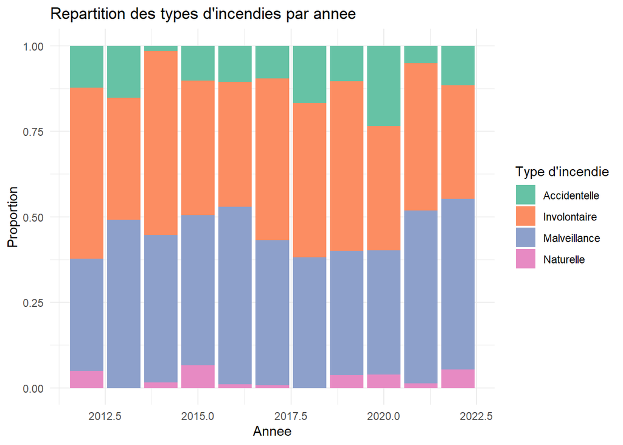

```r
incendiesregions <- read.csv("../Exports/export_incendiesregions.csv")
ggplot(incendiesregions, aes(x = annee, fill = nature_inc_prim)) +
  geom_bar(position = "fill") +
  labs(title = "Repartition des types d'incendies par annee",
       x = "Annee",
       y = "Proportion",
       fill = "Type d'incendie") +
  theme_minimal() +
  scale_fill_brewer(palette = "Set2")
```

1- **Analyse Informatique:**

Pour construire ce diagramme, nous avons d’abord importé les données dans une variable en utilisant la méthode **read.csv**, en précisant comme argument le chemin relatif du fichier CSV.

Après cette étape, nous utilisons la fonction **ggplot()** en précisant deux paramètres essentiels : la variable contenant les données sous format DataFrame et l’aes aesthetics spécifiant l’axe des x qui sera représenté en années. Nous indiquons également que les barres du graphique seront remplies par **nature_inc_prim**, définissant ainsi le genre d’incendies.

Par la suite, on utilise la méthode prédéfinie **geom_bar()** en configurant le paramètre de position sur ‘fill’ afin de normaliser les hauteurs des barres. Cela permet à chaque barre de représenter une proportion plutôt qu’une valeur absolue.

Chaque barre est donc graduée de 0 à 1, où chaque couleur remplie par **nature_inc_prim** symbolise une part du total.

Pour personnaliser notre diagramme à l’aide de la fonction prédéfinie **labs()**, nous indiquons le titre principal de notre graphique ainsi que les titres des axes x et y respectivement. Dans le but d’adapter le thème de notre graphique pour qu’il soit plus cohérent et contemporain, nous recourons à la fonction prédéfinie **theme_minimal()**.

On fait appel à la méthode prédéfinie **scale_fill_brewer()** pour appliquer une palette de couleurs définies par **RColorBrewer**. La palette **Set2** est employée pour attribuer une couleur différente aux diverses catégories de **nature_inc_prim**, de façon distincte.

2- **Analyse Statistique:**

Dans ce diagramme, nous procéderons à une analyse statistique de notre graphique.

**Il existe quatre catégories d’incendies :**

- Représenté par **Vert Clai**r, les incendies sont causés par des **accidents**.
- **Involontaires** sont représentés par des incendies causés par des **négligence**s ou des facteurs **non intentionnels**.
- **Malveillance** dépeinte par **Bleu** incendies **volontaires**.
- **Rose** représente les incendies provoqués par des **phénomènes naturels**.

Il est à noter que chaque histogramme annuel illustre la répartition proportionnelle des types d’incendies, avec une somme de ces proportions pour chaque année qui s’élève toujours à 1, soit 100%.

**Nous allons examiner de façon descriptive les tendances dans le temps.**

**Allons à la description des tendances globales :**

Cela indique une influence humaine significative qui pourrait être associée à des crimes, des conflits régionaux ou des activités de **déchiffrement illégal**.

En outre, même si les proportions varient **d’année en année**, on constate une stabilité relative par rapport aux autres années.

Il n’y a pas de modification radicale dans la distribution globale des **types d’incendies**.

Concernant la **relation temporelle**, lorsqu’on observe une **augmentation** de la malveillance, comme en **2015-2016** par exemple, le nombre **d’incendies involontaires** semble **diminuer**, suggérant une potentielle relation inverse entre ces deux catégories.

**Interprétation écologique et sociologique:**

Concernant les **incendies naturels**, le taux est extrêmement bas. Près de 5% mentionnent que les phénomènes naturels (comme la **foudre** ou les **éruptions volcaniques**) sont peu fréquents dans cette région ou à cette époque. Ceci nous donne la possibilité de représenter un environnement peu enclin aux feux de forêt, par exemple une **activité orageuse réduite**.

**Ces deux aspects pourraient suggérer plusieurs choses:**

- Des efforts de prévention
- Des changements dans les activités humaines

**Conclusion de la Problematique:**

Les sommets atteints en 2016-2017 indiquent des conditions climatiques extrêmes, tandis que la diminution après 2020 pourrait être le résultat de mesures de prévention efficaces.

Il est donc nécessaire d’ajuster les stratégies : combattre la malfaisance dans les zones basses et gérer les risques associés aux activités humaines dans les zones hautes.

##### 5.3.3.3 Variation de l’altitude par region

##### 5.3.3.4 Distance côtière et risque d’incendie

```r
library(tidyverse)
library(geosphere)
villes_cotieres <- tibble(
  ville = c("Brest", "Marseille", "Nice", "Biarritz", "Toulon"),
  lat = c(48.3904, 43.2965, 43.7102, 43.4832, 43.1242),
  lon = c(-4.4861, 5.3698, 7.2620, -1.5586, 5.9281)
)

df_incendies <- read_csv("../Data/donnees_geo.csv")
```

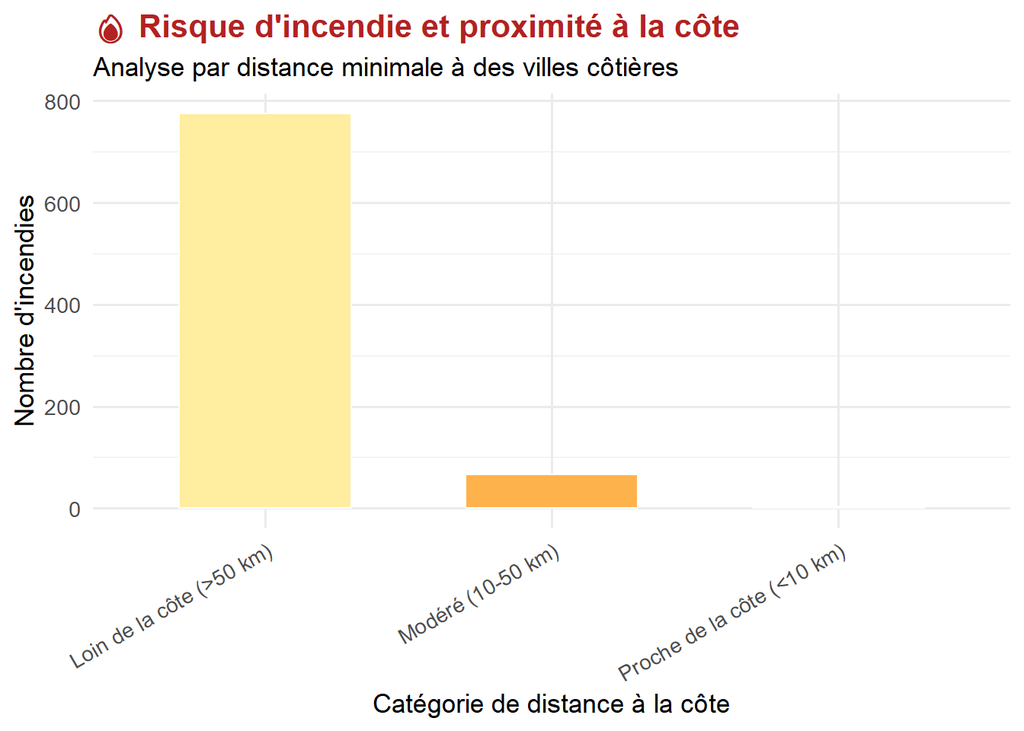

```r
df_incendies <- df_incendies %>%
  filter(!is.na(longitude), !is.na(latitude)) %>%
  rowwise() %>%
  mutate(
    distance_min = min(
      map2_dbl(
        villes_cotieres$lon, villes_cotieres$lat,
        ~ distVincentySphere(c(longitude, latitude), c(.x, .y))
      ) / 1000  # Convertir en kilomètres
    )
  ) %>%
  ungroup()

df_incendies <- df_incendies %>%
  mutate(
    categorie_distance_cote = case_when(
      distance_min <= 10 ~ "Proche de la côte (<10 km)",
      distance_min <= 50 ~ "Modéré (10-50 km)",
      distance_min > 50 ~ "Loin de la côte (>50 km)",
      TRUE ~ "Inconnu"
    )
  )

df_summary <- df_incendies %>%
  count(categorie_distance_cote)

ggplot(df_summary, aes(x = categorie_distance_cote, y = n, fill = categorie_distance_cote)) +
  geom_col(width = 0.6, color = "white") +
  scale_fill_brewer(palette = "YlOrRd") +
  labs(
    title = "🔥 Risque d'incendie et proximité à la côte",
    subtitle = "Analyse par distance minimale à des villes côtières",
    x = "Catégorie de distance à la côte",
    y = "Nombre d'incendies"
  ) +
  theme_minimal(base_size = 13) +
  theme(
    plot.title = element_text(face = "bold", color = "#B22222"),
    axis.text.x = element_text(angle = 30, hjust = 1),
    legend.position = "none"
  )
```

1- **Analyse Informatique**

On débute en déclarant les bibliothèques requises.

**tidyverse** est employé comme base principale pour la gestion des données et leur représentation visuelle, alors que **geosphere** offre les instruments indispensables pour les calculs de distance géographique, notamment le calcul précis de la distance géodésique à l’aide de la formule de **Vincenty**.

Puis, une base de données fictive est créée pour illustrer un échantillon de villes côtières en France.

Cette option facilite la modélisation de la présence côtière sans nécessiter l’utilisation de shapefiles géospatiaux complexes. Les villes choisies — Brest, Marseille, Nice, Biarritz, Toulon — offrent une représentation assez équilibrée du littoral français métropolitain, englobant les façades atlantique, méditerranéenne et de la Manche.

Ce sous-ensemble est élaboré à partir d’un tibble, un format moderne conçu pour le traitement vectoriel.

On procède ensuite à l’importation du jeu de données principal relatif aux incendies depuis un fichier CSV.

Ce document renferme les données géographiques exactes de chaque évènement (latitude, longitude), qui est une supposition cruciale du modèle.

Une étape de prétraitement est mise en place afin d’écarter les enregistrements incomplets, une démarche indispensable dans tout processus de données scientifiques assurant la solidité statistique et informatique des étapes suivantes.

L’analyse géographique proprement dite débute avec le calcul de la distance minimale entre chaque feu et tous les points côtiers.

Ce mécanisme est réalisé grâce à l’emploi de la fonction map2_dbl() de purrr, utilisée en parallèle avec distVincentySphere() pour produire une série de distances pour chaque point d’incendie, parmi lesquelles la distance minimale est sélectionnée.

Cette opération, réalisée ligne par ligne grâce à rowwise(), représente une méthode algorithmique claire, qui permet de reproduire le comportement d’une fonction vectorisée dans un contexte non spatial.

Suite au calcul des distances, le script effectue une classification en trois catégories distinctes et compréhensibles : proximité immédiate (<10 km), proximité modérée (10–50 km) et éloignement (>50 km).

Cette démarche convertit une mesure continue en une variable catégorique, facilitant ainsi l’analyse statistique descriptive et la représentation graphique.

Ce genre de discrétisation est crucial pour organiser l’information dans des contextes de prise de décision ou d’explication scientifique.

Le comptage (count()) permet ensuite de résumer l’information en termes de fréquences par classe de distance, constituant ainsi le fondement du graphe final.

Celui-ci, élaboré à l’aide de ggplot2, utilise une représentation par des barres colorées, avec des nuances chaudes (YlOrRd) qui suggèrent de manière intuitive la magnitude ou la sévérité du phénomène incendiaire.

L’option de la palette et l’élimination de la légende visuelle reflètent un désir de clarté et d’efficacité visuelle.

Pour finir, la mise en forme finale utilise un design minimaliste et épuré (theme_minimal()), associée à un titre attractif et une inclinaison partielle des labels de l’axe des abscisses. Le tout témoigne d’une réflexion approfondie sur la présentation des résultats, en mettant l’accent autant sur l’esthétisme de la représentation visuelle que sur sa précision scientifique.

2- **Analyse Statistique:**

Le graphique nommée « Risque d’incendie et proximité à la côte : Analyse par distance minimale à des villes côtières » offre une représentation graphique des informations concernant le nombre d’incendies en rapport avec leur éloignement minimal des cités côtières.

L’axe des abscisses divise les distances en trois catégories : « Loin de la côte (>50 km) », « Modéré (10-50 km) » et « Près de la côte (<10 km) ».

L’axe vertical représente le nombre d’incendies, avec une échelle qui varie de 0 à 800.

Cette recherche se situe dans le cadre des incendies en France, une nation où les feux de forêt et les incendies secondaires sont des enjeux primordiaux, particulièrement dans les zones méditerranéennes telles que le sud-est (Provence-Alpes-Côte d’Azur) et la Corse, qui sont situées près des côtes et exposées à un climat favorable aux incendies (sécheresse, vents puissants comme le mistral).

Pour établir les fondements de l’interprétation dans le cadre de cette analyse, il est nécessaire de définir plusieurs notions statistiques et géographiques :

- **Proximité à la côte :** L’évaluation de la distance minimale vers une ville côtière se fait en calculant la distance géodésique (en kilomètres) entre l’emplacement de l’incendie et la cité côtière la plus proche. Le graphique emploie des catégories (« <10 km », « 10-50 km », « >50 km ») qui représentent une transformation de cette variable continue en classes distinctes, une démarche fréquemment adoptée en statistique pour simplifier l’étude des tendances.
- **Risque d’incendie :** Le danger d’incendie est une évaluation probabiliste qui fusionne la probabilité qu’un incendie se produise et ses impacts éventuels. Il est affecté par des éléments biotiques (plantes, type de couverture forestière) et abiotiques (température, humidité, courant d’air). Dans le domaine de la statistique, ce risque peut être représenté à l’aide de distributions de Poisson pour les événements peu fréquents, ou via des modèles de régression spatiale afin d’inclure des covariables géographiques.

Le diagramme se présente sous la forme d’un histogramme simple comportant trois barres, chaque barre symbolisant une catégorie de distance par rapport à la côte.

L’altitude des barres représente le nombre d’incendies dans chaque catégorie.

Une première analyse révèle une disparité marquée entre les différentes catégories :

L’assignation est fortement déséquilibrée, affichant une concentration notable des incendies dans les régions situées à plus de 50 km des côtes.

Cette constatation indique un lien inverse entre la proximité du littoral et le nombre d’incendies, une supposition que nous allons vérifier statistiquement par la suite.

Ces pourcentages suggèrent que plus de 90 % des feux ont lieu à plus de 50 km des villes côtières, une tendance qui pourrait témoigner des divergences en termes de caractéristiques géographiques, climatiques ou humaines entre les régions côtières et les zones intérieures en France.

L’importante occurrence des incendies à plus de 50 km des côtes peut être attribuée à divers éléments liés aux aspects géographiques et météorologiques de la France :

- **Végétation et climat** : Les régions intérieures, telles que les forêts des Cévennes, des Alpes ou des Landes, ont généralement une couverture forestière plus dense et un climat plus sec que les zones côtières, où l’humidité de la mer peut diminuer le danger d’incendie.Dans l’Hexagone, les territoires méditerranéens (habituellement situés près du littoral) subissent des incendies, cependant, les régions arides situées à l’intérieur peuvent se révéler davantage exposées du fait de la densité de la végétation combustibles (pins, garrigue).
- **Activité humaine:** Les régions qui se trouvent loin des côtes peuvent comprendre des zones rurales ou agricoles où des activités telles que la pratique du brûlage agricole ou l’emploi de machines intensifient le danger d’un incendie.Les régions côtières, fréquemment urbanisées (comme Nice et Marseille), pourraient profiter d’infrastructures améliorées pour la prévention et les interventions rapides.
- **Conditions météorologiques:** Des incendies peuvent être déplacés sur de vastes étendues par des vents secs tels que le mistral, qui souffle dans le sud de la France. Cependant, leur impact est généralement modéré près du littoral en raison de l’humidité marine. En revanche, les conditions chaudes et sèches sont plus susceptibles d’affecter les zones intérieures.

Le faible nombre d’incendies près des côtes (<10 km) pourrait également refléter une densité de population plus élevée, avec des paysages plus urbanisés et moins de végétation inflammable.

Cependant, des exceptions existent, comme les incendies côtiers en Corse, où la proximité de la mer n’empêche pas les feux en raison de la topographie et de la végétation.

Test du Chi deux:

```r
library(tidyverse)
library(geosphere)

df_incendies <- read_csv("../Data/donnees_geo.csv")
```

```r
villes_cotieres <- tibble(
  ville = c("Brest", "Marseille", "Nice", "Biarritz", "Toulon"),
  lat = c(48.3904, 43.2965, 43.7102, 43.4832, 43.1242),
  lon = c(-4.4861, 5.3698, 7.2620, -1.5586, 5.9281)
)

df_incendies <- df_incendies %>%
  filter(!is.na(longitude), !is.na(latitude)) %>%
  rowwise() %>%
  mutate(
    distance_min = min(
      map2_dbl(
        villes_cotieres$lon, villes_cotieres$lat,
        ~ distVincentySphere(c(longitude, latitude), c(.x, .y))
      ) / 1000  # en kilomètres
    )
  ) %>%
  ungroup()

df_incendies <- df_incendies %>%
  mutate(
    categorie_distance_cote = case_when(
      distance_min <= 10 ~ "Proche de la côte (<10 km)",
      distance_min <= 50 ~ "Modéré (10-50 km)",
      distance_min > 50 ~ "Loin de la côte (>50 km)",
      TRUE ~ "Inconnu"
    )
  )

frequences_observees <- df_incendies %>%
  count(categorie_distance_cote) %>%
  filter(categorie_distance_cote != "Inconnu")

total <- sum(frequences_observees$n)
expected <- rep(total / nrow(frequences_observees), nrow(frequences_observees))

test_chi2 <- chisq.test(frequences_observees$n, p = rep(1 / nrow(frequences_observees), nrow(frequences_observees)))

print(frequences_observees)
```

```
## # A tibble: 3 × 2
##   categorie_distance_cote        n
##   <chr>                      <int>
## 1 Loin de la côte (>50 km)     775
## 2 Modéré (10-50 km)             66
## 3 Proche de la côte (<10 km)     4
```

```r
print(test_chi2)
```

```
##
##  Chi-squared test for given probabilities
##
## data:  frequences_observees$n
## X-squared = 1302.9, df = 2, p-value < 2.2e-16
```

Nous avons fait référence au test du Chi-Deux d’adéquation, une méthode statistique, pour comparer les fréquences observées dans diverses catégories à celles qui seraient attendues en supposant une uniformité.

**Nous avons donc établi deux suppositions :**

- **Hypothèse nulle (H₀)** : La répartition des incendies est uniforme parmi les trois classes de distance à la mer.Cela implique qu’il existe une chance identique d’apparition dans chaque catégorie.
- **Hypothèse alternative (H₁)**: La distribution des incendies n’est pas équitable. En d’autres termes, il y a un écart notable entre les fréquences observées et celles prévues, ce qui laisse supposer un impact de la proximité du littoral.

Avec une valeur du Chi-Deux de 1302.9 et un degré de liberté de 2, nous avons une valeur p très minuscule, inférieure à 0.0001, démontrant que la différence entre les fréquences observées et attendues est fortement significative.

La valeur p dénote la probabilité que l’écart entre les fréquences observées et anticipées soit le résultat du hasard. Une petite valeur p indique que nous pouvons refuser l’hypothèse nulle avec une grande certitude.

L’analyse du Chi-Deux nous indique que la distribution des incendies n’est pas uniforme entre les trois catégories de distance à la côte.

En conclusion, cette analyse statistique révèle une relation inverse marquée entre la proximité des villes côtières et le nombre d’incendies en France, avec plus de 90 % des incendies survenant à plus de 50 km des côtes.

#### 5.3.4 Urbanisation et activités humaines

##### 5.3.4.1 Comparaison des incendies entre les zones rurales et urbaines

##### 5.3.4.2 Activités humaines à risque (travaux/particuliers)

##### 5.3.4.3 Profil temporel des incendies criminels

###### 5.3.4.3.1 Profil horaire des incendies criminels

```r
library(tidyverse)
library(lubridate)

df <- read_csv("../Data/donnees_incendies.csv")
```

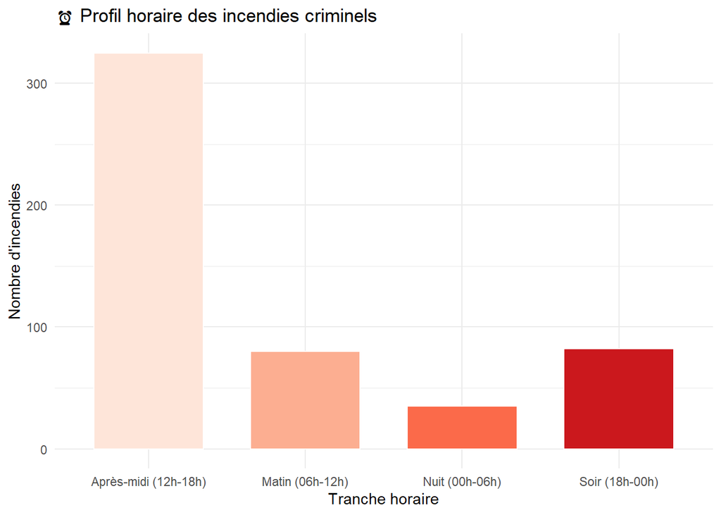

```r
df_malveillance <- df %>%
  filter(str_detect(tolower(nature_inc_prim), "malveillance"))

df_malveillance <- df_malveillance %>%
  mutate(
    heure_num = as.numeric(str_sub(heure, 1, 2)),
    tranche_horaire = case_when(
      heure_num >= 0 & heure_num < 6 ~ "Nuit (00h-06h)",
      heure_num >= 6 & heure_num < 12 ~ "Matin (06h-12h)",
      heure_num >= 12 & heure_num < 18 ~ "Après-midi (12h-18h)",
      heure_num >= 18 & heure_num < 24 ~ "Soir (18h-00h)",
      TRUE ~ "Heure inconnue"
    )
  )

ggplot(df_malveillance, aes(x = tranche_horaire, fill = tranche_horaire)) +
  geom_bar(width = 0.7, color = "white") +
  labs(
    title = "⏰ Profil horaire des incendies criminels",
    x = "Tranche horaire",
    y = "Nombre d'incendies"
  ) +
  scale_fill_brewer(palette = "Reds") +
  theme_minimal() +
  theme(legend.position = "none")
```

1- **Analyse Informatique:**

En premier lieu, les données ont été sélectionnées pour ne garder que les incendies de nature malveillante.

Ceci a été accompli en utilisant la fonction filter() de dplyr, couplée à l’usage de str_detect(), qui recherche la présence du mot « malveillance » dans la colonne nature_inc_prim.

Ce filtrage est crucial, puisqu’il assure que l’analyse se focalise exclusivement sur les incendies d’origine criminelle, évitant ainsi l’inclusion d’événements causés par des facteurs naturels ou accidentels.

Par la suite, l’élément horaire a été dérivé de la colonne heure.

L’heure a été obtenue en format numérique grâce à la fonction str_sub() et transformée en format numérique pour simplifier les opérations ultérieures.

Ces données horaires ont par la suite été réparties en différentes plages horaires, à savoir : « Nuit (00h-06h) », « Matin (06h-12h) », « Après-midi (12h-18h) » et « Soir (18h-00h) ».

Cette conversion a rendu possible la classification des incendies en fonction des moments précis de la journée, ce qui simplifie leur analyse comparative.

Ce graphique produit à partir de ces informations emploie un histogramme pour illustrer le nombre d’incendies criminels selon les plages horaires.

L’axe des x présente les différentes plages horaires, tandis que l’axe des y montre le nombre d’incendies observés pour chaque plage horaire.

Il n’y a pas de légende sur le graphique, car la couleur des barres sert déjà à distinguer chaque intervalle horaire.

2- **Analyse Statistique:**

Le diagramme nommé « Profil horaire des incendies criminels » représente la distribution des incendies criminels sur une durée de 24 heures, segmentée en quatre intervalles horaires spécifiques : « Matin (06h-12h) », « Après-midi (12h-18h) », « Soir (18h-00h) », et « Nuit (00h-06h) ».

L’axe horizontal illustre ces intervalles de temps, alors que l’axe vertical dénote le nombre d’incendies, sur une échelle qui varie de 0 à 350.

Cette étude vise à scruter la répartition des incendies criminels selon les moments de la journée, à déterminer les créneaux horaires les plus problématiques, à analyser les facteurs susceptibles d’expliquer ces fluctuations, et à débattre des conséquences statistiques et opérationnelles de ces découvertes dans un cadre de prévention et d’investigation.

Le diagramme est un histogramme basique où chaque barre représente un créneau horaire de 6 heures, englobant ainsi la totalité de la journée.

Chaque segment est représenté par une barre de couleur distincte : un rose clair pour l’« Après-midi (12h-18h) », un rose moyen pour le « Matin (06h-12h) », un rouge sombre pour le « Soir (18h-00h) » et un rouge plus pâle pour la « Nuit (00h-06h) ».

Une première analyse révèle une variation significative dans la fréquence des incendies criminels en fonction des plages horaires.

Les plages horaires « Matin (06h-12h) » et « Soir (18h-00h) » se positionnent à des niveaux moyens, avec des fréquences estimées respectivement autour de 75 et 80 incendies.

Cette représentation indique une importante occurrence des incendies criminels durant l’après-midi, ce qui pourrait témoigner de dynamiques comportementales, sociales ou environnementales propres à ce moment de la journée.

Test du Chi-Deux - **Hypothèse nulle (H0)** : Les incendies criminels sont répartis de manière uniforme parmi les différentes tranches horaires (“Nuit”, “Matin”, “Après-midi”, “Soir”). - **Hypothèse alternative (H1)** : La répartition des incendies criminels varie entre les différentes tranches horaires.

```r
library(tidyverse)
df <- read_csv("../Data/donnees_incendies.csv")
df_malveillance <- df %>%
  filter(str_detect(tolower(nature_inc_prim), "malveillance"))
df_malveillance <- df_malveillance %>%
  mutate(
    heure_num = as.numeric(str_sub(heure, 1, 2)),
    tranche_horaire = case_when(
      heure_num >= 0 & heure_num < 6 ~ "Nuit (00h-06h)",
      heure_num >= 6 & heure_num < 12 ~ "Matin (06h-12h)",
      heure_num >= 12 & heure_num < 18 ~ "Après-midi (12h-18h)",
      heure_num >= 18 & heure_num < 24 ~ "Soir (18h-00h)",
      TRUE ~ "Heure inconnue"
    )
  )
freq_observees <- df_malveillance %>%
  count(tranche_horaire)
total_incendies <- sum(freq_observees$n)
freq_attendues <- rep(total_incendies / nrow(freq_observees), nrow(freq_observees))
test_chi2 <- chisq.test(freq_observees$n, p = rep(1/nrow(freq_observees), nrow(freq_observees)), rescale.p = TRUE)
test_chi2
```

```
##
##  Chi-squared test for given probabilities
##
## data:  freq_observees$n
## X-squared = 397.34, df = 3, p-value < 2.2e-16
```

Cela signifie que nous rejetons l’hypothèse nulle et acceptons l’hypothèse alternative, concluant ainsi que la répartition des incendies criminels n’est pas uniforme entre les tranches horaires. Ce résultat montre que certains moments de la journée ou de la nuit sont plus propices aux actes criminels, suggérant un comportement influencé par des facteurs temporels.

###### 5.3.4.3.2 Répartition mensuelle des incendies malveillants

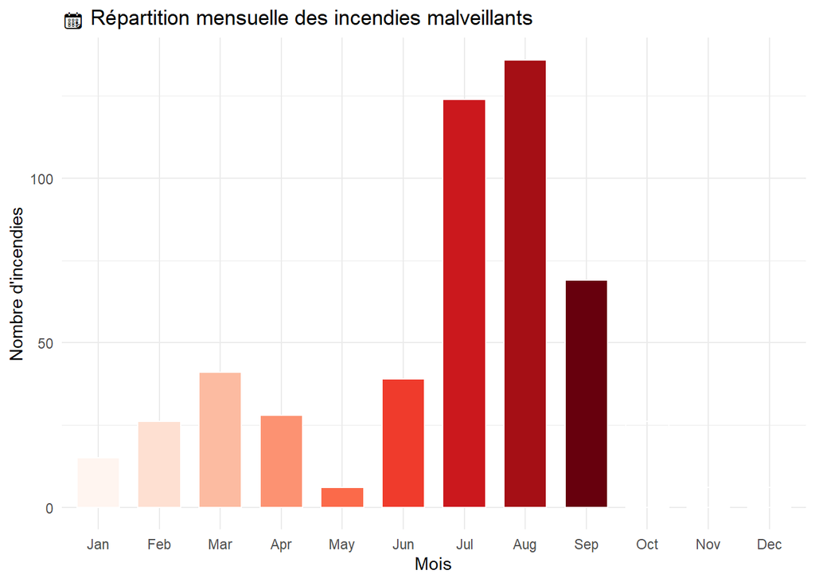

```r
df_malveillance <- df_malveillance %>%
  mutate(
    heure_num = as.numeric(str_sub(heure, 1, 2)),
    tranche_horaire = case_when(
      heure_num >= 0 & heure_num < 6 ~ "Nuit (00h-06h)",
      heure_num >= 6 & heure_num < 12 ~ "Matin (06h-12h)",
      heure_num >= 12 & heure_num < 18 ~ "Après-midi (12h-18h)",
      heure_num >= 18 & heure_num < 24 ~ "Soir (18h-00h)",
      TRUE ~ "Heure inconnue"
    )
  )
df_malveillance <- df_malveillance %>%
  mutate(mois = factor(mois, levels = month.abb))  # Jan, Feb, ..., Dec

ggplot(df_malveillance, aes(x = mois, fill = mois)) +
  geom_bar(width = 0.7, color = "white") +
  labs(
    title = "📆 Répartition mensuelle des incendies malveillants",
    x = "Mois",
    y = "Nombre d'incendies"
  ) +
  scale_fill_brewer(palette = "Reds") +
  theme_minimal() +
  theme(legend.position = "none")
```

1- **Analyse Informatique:**

La première phase de cette étude implique l’organisation des données pour assurer leur interprétation et présentation correctes.

Dans ce cas, nous avons employé la colonne indiquant les mois, qui était initialement présentée sous forme d’abréviations (par exemple, « Jan », « Feb »), mais de manière désordonnée.

Afin d’assurer une représentation précise sur le graphique, les mois ont été transformés en un facteur avec des niveaux qui correspondent à la séquence naturelle du calendrier (de janvier à décembre). Cette étape est cruciale, car elle assure que les mois seront présentés dans l’ordre chronologique approprié sur le graphique, facilitant ainsi une analyse précise de la tendance mensuelle des incendies.

Après traitement des données, un diagramme à barres est mis en place pour illustrer le nombre de feux criminels par mois au cours de l’année.

Sur le graphique, chaque barre illustre un mois, et sa hauteur indique le nombre d’incendies qui se sont produits durant ce mois spécifique.

L’emploi d’un diagramme à barres facilite une comparaison entre les divers mois, mettant en évidence instantanément quels mois présentent un nombre supérieur ou inférieur d’incendies criminels.

L’utilisation d’une gamme de couleurs « Reds » souligne aussi les fluctuations dans la force des incendies, des teintes plus éclatantes signalant des phases d’activité criminelle accrue.

L’étude du graphique facilite l’identification des tendances saisonnières ou mensuelles. Si certaines barres semblent manifestement plus élevées que d’autres, cela indique que les actes criminels liés aux incendies ont lieu plus fréquemment à certains mois.

Par exemple, si l’on observe des pics pendant les mois d’été, cela peut suggérer que les incendies criminels sont liés à des éléments climatiques comme des chaleurs plus intenses et une augmentation de l’activité extérieure, souvent favorables à ce genre de méfait.

2- **Analyse Statistique:**

Le diagramme est une représentation sous forme d’histogramme où chaque colonne symbolise un mois de l’année, teintée dans des nuances de rouge allant du plus clair (janvier) au plus soutenu (septembre).

Cette distribution mensuelle illustre une courbe en forme de cloche asymétrique, centrée autour de l’été, présentant des extrémités basses en début et fin d’année.

Sans aucun doute, l’été est la saison la plus cruciale, regroupant plus de la moitié des feux criminels annuels.

Les mois de juillet et août, enregistrant respectivement 124 et 136 incendies, constituent un sommet estival remarquable qui laisse penser à une recrudescence de l’activité criminelle durant cette période.

Toutefois, bien que le printemps se caractérise par une certaine constance en mars et avril, il est surtout marqué par un net déclin en mai, qui semble presque épargné par les feux malintentionnés.

Cette répartition saisonnière n’est pas régulière : l’été se distingue comme une phase de crise, alors que le reste de l’année présente une criminalité plus tempérée, interrompue par l’irrégularité de mai.

Cette périodicité indique des éléments saisonniers ou comportementaux qui nécessitent une étude détaillée.

Ce pic estival, associé aux schémas horaires des graphiques antérieurs (12h-18h pour les incendies criminels, 15h-21h pour les secondaires), fournit une vision précise des moments critiques : les chaudes après-midi d’été.

##### 5.3.4.4 Facteurs prédictifs des incendies criminels

**Analyse de la répartition es incendies criminels en fonction de la température**

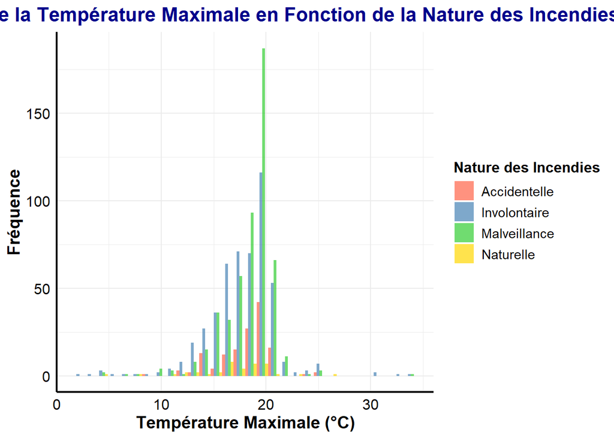

```r
  library(ggplot2)

  donnees_combinees<- read.csv("../Exports/export_incendies_criminels.csv")
  library(ggplot2)

  ggplot(donnees_combinees, aes(x = tmax_med, fill = nature_inc_prim)) +
    geom_histogram(position = "dodge", bins = 30, alpha = 0.7) +  # Slight transparency for better visibility
    scale_fill_manual(values = c("#FF6347", "#4682B4", "#32CD32", "#FFD700")) +  # Custom colors for the fill
    labs(
      title = "Distribution de la Température Maximale en Fonction de la Nature des Incendies",
      x = "Température Maximale (°C)",  # More specific axis label
      y = "Fréquence",  # More specific y-axis label
      fill = "Nature des Incendies"  # Label for the fill legend
    ) +
    theme_minimal() +
    theme(
      plot.title = element_text(size = 16, face = "bold", color = "darkblue", hjust = 0.5),  # Title styling
      axis.title.x = element_text(size = 14, face = "bold", color = "black"),  # X-axis title styling
      axis.title.y = element_text(size = 14, face = "bold", color = "black"),  # Y-axis title styling
      axis.text = element_text(size = 12, color = "black"),
      legend.title = element_text(size = 12, face = "bold"),
      legend.text = element_text(size = 11)
    ) +
    theme(axis.line = element_line(size = 0.8, color = "black"))
```

**Analyse Informatique**

La première ligne de code, library(ggplot2), sert à importer la bibliothèque ggplot2 dans R.

Cette librairie est réputée pour sa capacité à produire des graphiques élégants et personnalisables.

En substance, elle offre la possibilité de créer des visualisations en superposant des couches, à l’image d’un dessin progressif : commencer par les données, puis passer aux formes, aux couleurs, et ainsi de suite.

Ici, on la charge afin de pouvoir exploiter ses fonctionnalités par la suite.

Le code contient deux appels à la bibliothèque ggplot2, alors qu’un seul est nécessaire. En effet, R ne chargerait pas deux fois la même ressource — c’est une redondance superflue.

Puis, on a utilisé la commande **données_combinees <- read.csv(“../Exports/export_incendies_criminels.csv”)** pour lire le fichier CSV.

Cette ligne est cruciale :

elle s’applique à un fichier CSV (un tableau séparé par des virgules, semblable à celui d’Excel) nommé export_incendies_criminels.csv, situé dans un répertoire dénommé Exports, qui se trouve un niveau au-dessus du répertoire courant (le ../ signifie cela).

La fonction read.csv interprète ce fichier et le convertit en un tableau de données dans R, connu sous le nom de data frame.

La variable donnees_combinees contient ce tableau.

Il est supposé que ce document renferme des renseignements concernant les incendies, incluant des colonnes telles que tmax_med (probablement la température maximale) et nature_inc_prim (le genre d’incendie).

Si le fichier n’existe pas ou si le chemin est faux, ça planterait direct avec une erreur.

Le travail concret débute avec ggplot(donnees_combinees, aes(x = tmax_med, fill = nature_inc_prim)).

Il s’agit du fond du graphique.On utilise les données combinées comme référence, et aes() (pour « aesthetics ») définit comment les disposer.

Dans ce contexte, x = tmax_med indique que la température maximale est représentée sur l’axe horizontal (l’axe des x), tandis que fill = nature_inc_prim signifie que les couleurs des barres sont déterminées par la catégorie d’incendie.

Par exemple, si nature_inc_prim présente des valeurs telles que « criminel » ou « accidentel », chaque catégorie se verra attribuer une couleur distincte.

Cette ligne n’est pas encore définie, elle sert simplement à préparer le terrain.

Ensuite, on intègre geom_histogram(position = “dodge”, bins = 30, alpha = 0.7).

C’est là que se trouve vraiment l partie qui trace le graphique. geom_histogram génère un histogramme, qui est une catégorie de diagramme où l’on dénombre le nombre d’occurrences d’une valeur (dans ce cas tmax_med) dans divers intervalles.

Les bins = 30 répartissent les températures en 30 petites catégories afin de constituer les histogrammes.position = « dodge » fait que les barres de chaque catégorie d’incendie sont placées l’une à côté de l’autre plutôt qu’empilées, ce qui facilite la comparaison.

Avec alpha fixé à 0.7, les barres deviennent légèrement transparentes (de 0 pour invisible à 1 pour opaque), ce qui est utile si elles se superposent, afin de mettre en évidence les détails.

Par la suite, on utilise scale_fill_manual(values = c(“#FF6347”, “#4682B4”, “#32CD32”, “#FFD700”)). Cette ligne sélectionne les teintes des barres.

Des codes tels que #FF6347 représentent des valeurs hexadécimales, indiquant à la machine quelle teinte appliquer (dans ce cas, rouge tomate, bleu acier, vert citron et jaune doré).

Cela implique l’existence de quatre catégories distinctes d’incendies dans nature_inc_prim.

Si le nombre n’est pas adéquat, cela pourrait causer des soucis : un excès de types entraîne une répétition des couleurs ; une carence, et certaines teintes deviennent inutiles.

C’est une personnalisation agréable pour améliorer l’aspect et la clarté du graphique.

Par la suite, labs(…) appose des étiquettes pour assurer une lisibilité parfaite.

Le titre long : « Distribution de la Température Maximale en Fonction de la Nature des Incendies » décrit précisément ce qu’on examine.

x = “Température Maximale (°C)” modifie le nom de l’axe horizontal pour qu’il soit plus explicite que simplement « tmax_med », tandis que y = « Fréquence » signifie que l’axe vertical représente le nombre d’observations dans chaque colonne.

Finalement, fill = “Nature des Incendies” attribue un titre à la légende, indiquant quelle couleur correspond à quel type d’incendie.

Cela rend le graphique simple à interpréter, même pour une personne qui n’est pas familière avec les données.

theme_minimal() offre un style épuré et minimaliste, avec un fond blanc et une absence de lignes superflues - cela met l’accent sur les données.

Cependant, nous allons encore plus loin dans la personnalisation avec le thème (…).

Cela donne un aspect professionnel et facilement lisible.

Finalement, theme(axis.line = element_line(size = 0.8, color = “black”)) insère des lignes noires d’épaisseur 0.8 sur les axes, servant ainsi de cadre.

Cela définit les contours du graphique et lui donne plus de clarté.

En fin de compte, ce code génère un histogramme qui illustre la répartition des températures maximales selon les catégories d’incendies, avec des barres colorées disposées côte à côte, une conception limpide et des étiquettes judicieusement élaborées.

C’est courant d’examiner des données pour vérifier s’il existe une relation entre la température et le type des incendies.

**Analyse Statistique**

Le diagramme représente un histogramme illustrant la répartition de la température maximale (en °C) selon le type d’incendie, en distinguant quatre catégories : « Accidentelle » (rose), « Involontaire » (bleu), « Malveillance » (vert), et « Naturelle » (jaune).

L’axe horizontal illustre la température maximale, qui varie de 0 à 35 °C, tandis que l’axe vertical dénote la fréquence, soit le nombre d’incendies pour chaque plage de température.

L’option position = “dodge” permet d’afficher les barres côte à côte, facilitant ainsi la comparaison des distributions des différentes sortes d’incendies.

Le diagramme est explicite, en présentant des couleurs distinctives et des libellés nettement définis, ce qui rend l’analyse plus aisée.

En analysant la distribution globale, on note que la plupart des feux, peu importe les types, se situent entre 15 et 25 °C.

C’est au sein de cette fourchette que les pics sont les plus importants, particulièrement aux environs de 20 °C où le taux se rapproche presque de 175 pour la classe « Malveillance » (vert).

Cela indique que les incendies, en particulier ceux causés intentionnellement, ont tendance à être plus courants à des températures modérées, ni trop basses ni trop élevées.

Hors de cette fourchette, les occurrences diminuent : on observe très peu d’incendies en dessous de 10 °C ou au-delà de 30 °C, avec quelques pics isolés signalant des événements rares.

Cette courbe de distribution en forme de cloche (légèrement asymétrique) est caractéristique des données telles que la température, qui présente fréquemment une plage « préférée » dans des conditions naturelles.

En analysant chaque catégorie séparément, on constate que la catégorie « Malveillance » (en vert) prédomine nettement en termes de fréquence.

La catégorie « Involontaire » (bleu) suit également, présentant des occurrences moins fréquentes mais toujours notables, souvent dans la fourchette de 50 à 100 au sein du même intervalle de température.

Les incendies dits « accidentels » (indiqués en rose) et « naturels » (indiqués en jaune) se produisent beaucoup moins fréquemment, leurs barres ne dépassant guère les 50, sauf à certains endroits.

Par exemple, les feux « naturels » présentent une légère hausse autour de 20 °C, cependant leur occurrence demeure inférieure comparée à d’autres.

Un aspect intéressant concerne la forme des distributions pour chaque catégorie. On observe toutes une tendance comparable, culminant autour de 15-25 °C, néanmoins elles varient en amplitude.

Les incendies « Accidentels » et « Involontaires » présentent des distributions intermédiaires, avec des sommets moins prononcés que « Malveillance », mais plus perceptibles que « Naturelle ».

Concernant le lien entre la température et les types d’incendies, le diagramme ne révèle pas de variation marquante dans la forme des distributions en fonction des catégories.

On observe que tous les types d’incendies semblent survenir principalement dans la même plage de température (15-25 °C), ce qui laisse supposer que la température maximale n’est peut-être pas un critère décisif pour différencier les divers types d’incendies.

Toutefois, le taux nettement plus élevé d’incendies attribués à la « Malveillance » pourrait suggérer que d’autres éléments, tels que des actions humaines, ont une influence plus significative dans cette catégorie.

Pour finir, on doit prendre note de certaines observations concernant les extrêmes.

Sous 10 °C et au-delà de 30 °C, les occurrences sont minimes pour toutes les classes, toutefois, on observe quelques barres isolées.

Cela pourrait être attribué à des circonstances exceptionnelles, telles que des sécheresses extrêmes pour les incendies naturels à haute température.

Ces occurrences peu fréquentes pourraient constituer des anomalies, et il serait pertinent de déterminer si elles sont authentiques ou si elles résultent d’imperfections dans les données.

Pour résumer, ce graphique illustre que les incendies, particulièrement ceux causés par des actes malveillants, se produisent plus souvent à des températures modérées (15-25 °C), et il n’y a pas de grandes variations dans la forme des distributions entre les différentes catégories.

Le prépondérance des incendies « Malveillance » indique que les facteurs humains sont sans doute plus influents que la température à eux seuls.

Pour aller plus loin, nous pourrions envisager d’examiner d’autres variables ou réaliser des analyses statistiques afin de déterminer si les différences relevées ont une signification.

Ce type d’analyse constitue un excellent point de départ pour appréhender les données et formuler des interrogations plus spécifiques.

##### 5.3.4.5 Impact cumulé du climat et de l’urbanisation

1- **Comment le niveau de risque (rr_med) varie-t-il selon la nature des incidents secondaires dans les zones urbaines sèches ?**

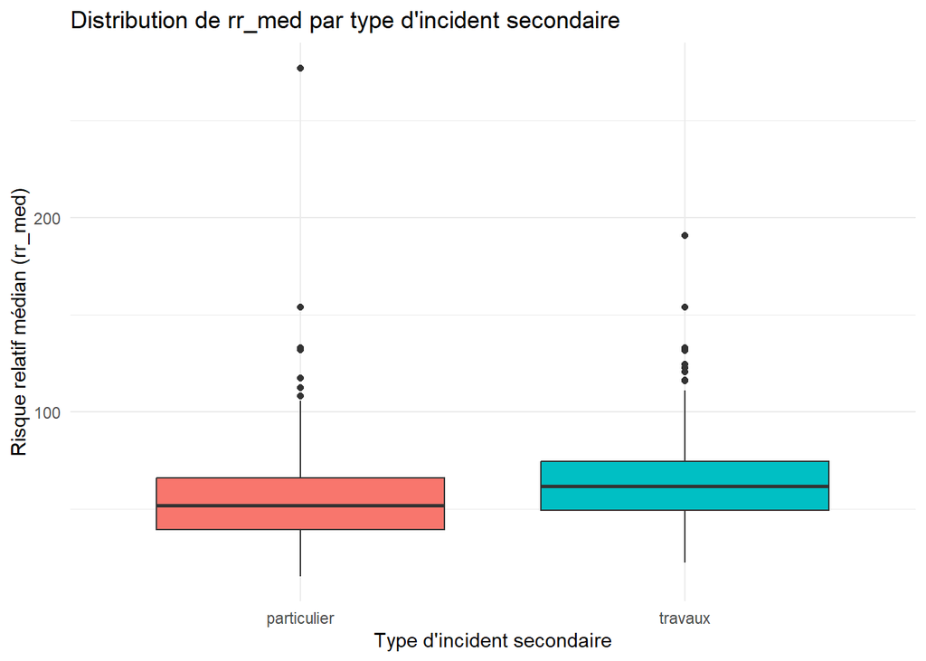

```r
library(ggplot2)
library(dplyr)
library(sf)
library(readr)

data <- read_csv("../Exports/export_impactclimaturbanisation.csv")
data_clean <- data %>%
  filter(!is.na(rr_med), !is.na(nature_sec_inc))

ggplot(data_clean, aes(x = nature_sec_inc, y = rr_med, fill = nature_sec_inc)) +
  geom_boxplot() +
  theme_minimal() +
  labs(title = "Distribution de rr_med par type d'incident secondaire",
       x = "Type d'incident secondaire",
       y = "Risque relatif médian (rr_med)") +
  theme(legend.position = "none")
```

**Analyse Informatique**

Pour élaborer ce diagramme, nous avons commencé par importer diverses bibliothèques indispensables comme ggplot2 pour la représentation graphique, dplyr pour le traitement de données, sf pour la gestion spatiale et readr pour l’importation de documents CSV.

Par la suite, nous avons importé notre jeu de données en utilisant la fonction read_csv(), en indiquant le chemin relatif vers le fichier CSV en question. Les informations sont donc conservées dans la variable data.

Pour garantir la qualité des données avant leur représentation graphique, nous avons réalisé un prétraitement en utilisant la fonction filter() provenant de dplyr. Nous avons sélectionné les lignes en éliminant celles qui comportent des valeurs absentes dans les colonnes rr_med (risque relatif médian) et nature_sec_inc (nature de l’incident secondaire). Ce nettoyage est enregistré dans une nouvelle variable appelée data_clean.

Pour créer des graphiques, nous recourons à la fonction ggplot(), dans laquelle nous mentionnons la variable contenant nos données épurées et définissons l’esthétique aes(), où nous précisons que l’axe des x dépeindra la nature_sec_inc, tandis que l’axe des y mettra en lumière les valeurs de rr_med.

On fait ensuite appel à la fonction préétablie geom_boxplot() pour créer un boxplot, offrant une représentation de la distribution du rr_med pour chaque catégorie d’incident secondaire. Nous appliquons une couleur de remplissage (fill) en fonction de nature_sec_inc, permettant d’attribuer une couleur distincte à chaque catégorie.

Nous adaptons finalement le graphique en utilisant la fonction labs(), afin de définir le titre principal et les intitulés des axes x et y. Pour donner un aspect plus contemporain et minimaliste au graphique, nous utilisons le thème prédéfini theme_minimal().

Pour finir, nous éliminons la légende en appliquant theme(legend.position = “none”), étant donné que les informations relatives aux catégories sont déjà visibles sur l’axe des x.

**Analyse Statistique**

Le diagramme illustre un boxplot, également connu sous le nom de boîte à moustaches, qui compare la répartition du niveau médian de risque **rr_med** en fonction de deux catégories d’incidents secondaires : **particulier** et **travaux**.

L’axe vertical indique le niveau de risque médian, tandis que l’axe horizontal illustre les différentes catégories d’incendies secondaires.

**D’après ce graphique, nous serons en mesure de repérer des aspects cruciaux dans notre étude statistique :**

La ligne centrale de la boîte, représentant la médiane de la distribution, est appelée la médiane.

L’interquartile représente l’intervalle entre le premier quartile et le troisième quartile, illustrant la dispersion des 50% de données centrales à travers la boîte elle-même.

Les lignes qui se déploient à partir des boîtes illustrent la portée des données.

**En ce qui concernes les incendies de type particulier:**

La médiane est aux alentours de 50. L’IQR varie approximativement entre 40 et 60, ce qui indique une dispersion modérée des données.

**Pour les incendies de type travaux:**

Dans les zones urbaines sèches, des éléments tels que la densité de population, l’état des infrastructures ou les conditions météorologiques peuvent influencer les incendies secondaires.

Dans les cas d’incendies atypiques, les valeurs extrêmes pourraient indiquer des sinistres exceptionnels et sévères tels que des fuites de gaz, des incendies ou des accidents impliquant des substances périlleuses qui ont un impact accru dans un environnement aride.

Dans les incendies liés aux travaux, une variabilité légèrement plus élevée est observée, mais les extrêmes sont moins marqués. Cela suggère que les opérations telles que les chantiers routiers ou la distribution de réseaux entraînent des risques plus prévisibles, bien qu’ils dépendent de la qualité de gestion des travaux et des conditions locales.

Toutefois, certaines sortes d’incendies présentent des dangers nettement plus importants, ce qui indique qu’ils peuvent parfois avoir un effet bien plus considérable.

2- **Quelle est la distribution générale du risque (rr_med) dans l’ensemble des zones étudiées ?**

```r
data <- read_csv("../Exports/export_impactclimaturbanisation.csv")
```

[figure not shown]

```r
data_clean <- data %>%
  filter(!is.na(rr_med), !is.na(nature_sec_inc))
ggplot(data_clean, aes(x = rr_med)) +
  geom_histogram(binwidth = 0.5, fill = "#2c7fb8", color = "white") +
  theme_minimal() +
  labs(title = "Histogramme de rr_med",
       x = "Risque relatif médian",
       y = "Nombre d'occurrences")
```

```r
mean_rr_med <- mean(data_clean$rr_med, na.rm = TRUE)
median_rr_med <- median(data_clean$rr_med, na.rm = TRUE)
sd_rr_med <- sd(data_clean$rr_med, na.rm = TRUE)
skewness_rr_med <- e1071::skewness(data_clean$rr_med, na.rm = TRUE)  # Calcul de l'asymétrie
```

**Analyse Informatique**

À cette étape, nous avons rechargé notre ensemble de données en utilisant la fonction read_csv(), en indiquant le chemin relatif vers le fichier CSV.

Ainsi, les données sont conservées dans la variable nommée data. Par la suite, nous avons fait appel à la variable data_clean, qui avait déjà été purgée des valeurs manquantes.

Pour représenter graphiquement, nous avons conçu un histogramme à l’aide de la fonction ggplot(), en positionnant rr_med sur l’axe des x.

Nous avons paramétré la fonction geom_histogram() avec une largeur de bin de 0.5, ce qui offre la possibilité de gérer l’amplitude des barres de l’histogramme, et un ton de remplissage #2c7fb8 (un bleu sombre), alors que le contour des barres est teinté en blanc pour une distinction nette. Cette sélection de style garantit une lecture plaisante.

L’aspect épuré et contemporain du graphique a été obtenu grâce à l’application du thème theme_minimal(). Par ailleurs, la fonction labs() a permis d’intégrer un titre principal au graphique ainsi que des intitulés pour les axes x et y, en lien avec le risque relatif médian et le nombre d’occurrences des diverses valeurs.

Parallèlement à la visualisation, nous avons réalisé certains calculs statistiques concernant la colonne rr_med du jeu de données nettoyé.

Nous avons commencé par déterminer la moyenne de rr_med en utilisant la fonction mean(), en précisant l’argument na.rm = TRUE afin d’éliminer les valeurs absentes.

Par ailleurs, la fonction median() est utilisée pour déterminer la médiane et sd() pour calculer l’écart-type. Pour finir, nous avons employé la fonction skewness() du package e1071 afin d’évaluer l’asymétrie de la distribution de rr_med.

**Analyse Statistique**

Notre diagramme illustre la répartition du risque relatif médian, où notre axe des x montre le risque relatif médian variant de 0 à 250. L’échelle des ordonnées indique le nombre d’apparitions pour chaque plage de **rr_med**.

La plupart des valeurs de **rr_med** se regroupent entre 0 et 100, avec une concentration notable autour de 50. La distribution présente une forte asymétrie vers la droite avec une longue queue du côté droit, mais elle comporte peu de données au-delà de 100.

Le sommet de l’histogramme se trouve approximativement autour de 50, ce qui indique que la valeur la plus courante de **rr_med** est proche de 50.

Étant donné l’asymétrie à droite, la médiane est légèrement inférieure à la moyenne, mais elle se situe près de 50.

L’asymétrie à droite est la raison pour laquelle la moyenne dépasse 50.

Les valeurs de **rr_med** varient entre 0 et 250. Concernant la variabilité, on observe une concentration notable autour de 50, cependant la présence de valeurs atypiques signale une grande variabilité dans les situations extrêmes.

La répartition du risque relatif médian **rr_median** dans l’ensemble des zones examinées présente une forte asymétrie à droite. Cela indique que la majorité des zones affichent un niveau de risque relativement bas autour de 50, cependant, il y a tout de même des situations rares où le risque atteint des niveaux extrêmement élevés jusqu’à 250.

Cette asymétrie indique que les zones étudiées, probablement des régions urbaines sèches, présentent un faible risque. Cependant, des incendies ciblés ou des circonstances particulières peuvent conduire à des niveaux de risque exceptionnellement élevés.

Cet histogramme présente une distribution générale qui est en adéquation avec notre sous-problème précédent. La concentration autour de 50 correspond aux médianes des deux groupes, et les valeurs aberrantes visibles dans les boxplots sont à l’origine de la longue queue sur la droite de l’histogramme.

La plupart des régions examinées présentent un risque faible à modéré, généralement autour de 50. Cependant, des incendies sporadiques engendrent parfois des risques très élevés.

Cela reflète des conditions particulières propres aux zones urbaines sèches, telles qu’une vulnérabilité accrue aux incendies ou une mauvaise gestion d’infrastructures essentielles.

3. **Quels types d’incidents secondaires sont les plus fréquents dans les zones urbaines (potentiellement sèches) ?**

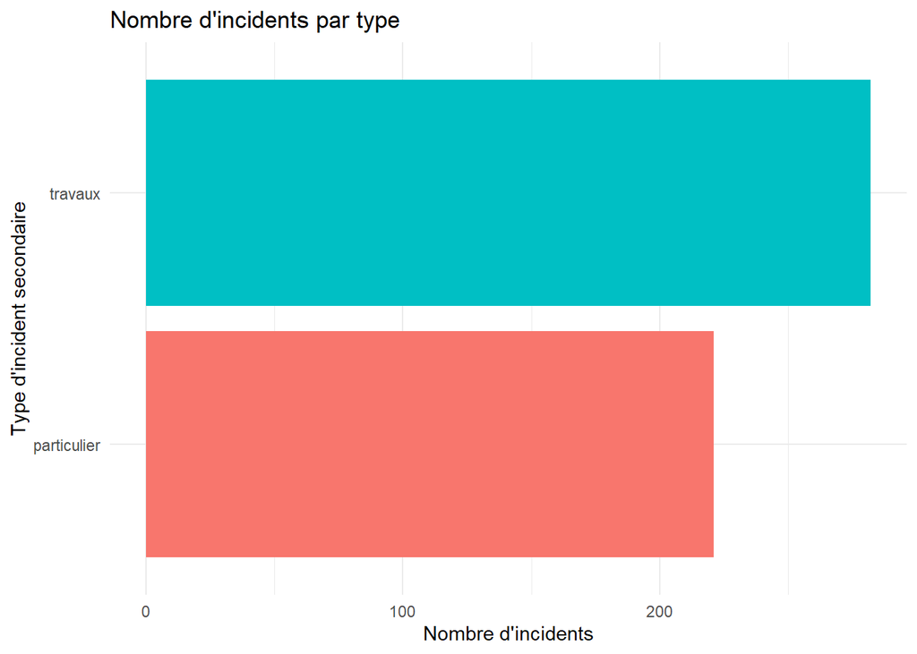

```r
data_clean %>%
  count(nature_sec_inc) %>%
  ggplot(aes(x = reorder(nature_sec_inc, n), y = n, fill = nature_sec_inc)) +
  geom_bar(stat = "identity") +
  coord_flip() +
  theme_minimal() +
  labs(title = "Nombre d'incidents par type",
       x = "Type d'incident secondaire",
       y = "Nombre d'incidents") +
  theme(legend.position = "none")
```

**Analyse Informatique**

Lors de cette phase, nous avons fait appel à la fonction count() issue du package dplyr afin de déterminer le nombre d’incidents selon chaque type d’incident secondaire.

Nous avons par la suite enregistré le résultat dans une nouvelle variable afin de rendre les données prêtes pour leur présentation visuelle.

Nous avons fait appel à ggplot() pour créer le graphique, en indiquant comme variables l’axe x qui illustre les catégories d’incidents secondaires, agencées en fonction du nombre d’incidents (reorder(nature_sec_inc, n)).

La direction des y indique le nombre d’incidents (n). Nous avons opté pour l’utilisation d’un graphique à barres via geom_bar(stat = “identity”), ce qui facilite la présentation directe des valeurs d’occurrences, évitant ainsi le calcul de proportions ou de fréquences relatives.

Pour faciliter la lecture, nous avons intégré la fonction coord_flip() qui permet de renverser les axes afin de présenter les barres sur un format horizontal. Cela rend la lecture des étiquettes sur l’axe des x plus aisée, en particulier lorsqu’il y a un grand nombre de types d’incidents.

Nous avons utilisé le thème theme_minimal() pour donner un aspect contemporain et minimaliste, tandis que la fonction labs() a été mise en œuvre pour incorporer un titre principal, ainsi que ceux des axes x et y.

Finalement, nous avons éliminé la légende en appliquant theme(legend.position = “none”), car les détails sont déjà manifestement représentés sur l’axe des x.

**Analyse Statistique**

Ce graphique comprend deux catégories d’incendies secondaires : les travaux et les particuliers.

Les zones urbaines désignent des espaces densément peuplés dotés d’infrastructures. Les incidents secondaires peuvent englober des perturbations associées à des travaux publics ou à des actions individuelles.

Les zones qui pourraient être sèches Cela indique des zones où l’approvisionnement en eau est restreint, soit à cause de conditions climatiques telles que la sécheresse saisonnière ou persistante, soit en raison de pression sur les ressources hydriques urbaines, comme la surexploitation, l’infrastructure vieillissante, etc.

Les incendies attribués aux travaux constituent 57% du total, tandis que ceux correspondant à des types d’incendies **particuliers** en représentent approximativement 43%.

Les incendies associés aux travaux ont généralement lieu plus souvent en milieu urbain, du fait des infrastructures requérant des interventions régulières, notamment dans les zones à forte densité.

**Pourquoi les travaux sont-ils plus frequents?**

Dans les régions urbaines, les systèmes d’eau et de drainage sont fréquemment vétustes. Par exemple, aux États-Unis, certaines conduites ont plus d’un siècle. En période de sécheresse, le sol peut se rétracter, ce qui entraîne des fissures et des fuites nécessitant des réparations régulières.

Les villes situées dans des régions arides mettent en place des infrastructures afin de préserver l’eau.

L’élargissement des zones urbaines requiert des efforts continus pour l’établissement de nouvelles routes, bâtiments et réseaux. Ces infrastructures peuvent être à l’origine d’incendies accidentels ou de pannes de services, sans compter les accidents qui peuvent survenir sur les chantiers.

Pour minimiser ces occurrences, un mélange d’améliorations des infrastructures, de campagnes de sensibilisation et de politiques sur mesure s’avère indispensable.

**Conclusion**

L’analyse statistique effectuée souligne l’effet conjugué de la sécheresse et de l’urbanisation sur la répartition et le caractère des risques en milieu urbain. En général, le risque relatif médian (rr_med) se situe à une valeur intermédiaire proche de 50, indiquant une condition plutôt stable pour la plupart des incidents constatés.

Néanmoins, la présence de valeurs extrêmes, qui peuvent parfois atteindre 250, suggère que des circonstances exceptionnelles, généralement associées à des événements d’ampleur ou à des pannes critiques d’infrastructures, peuvent considérablement augmenter le degré de risque.

En outre, l’analyse des incidents montre une distinction marquée entre les sinistres classés comme « travaux » et ceux identifiés comme « particulier ».

Les incidents liés aux chantiers se produisent non seulement plus souvent – constituant approximativement 57 % des situations – mais sont également un peu plus variables en termes de degré de risque.

Cette prévalence des incidents associés aux travaux dans les régions urbaines sèches illustre la valeur cruciale des infrastructures dans ces environnements, où les systèmes techniques et les sites de construction sont constamment présents et fréquemment soumis à des conditions climatiques rigoureuses.

Effectivement, des facteurs tels que la sécheresse, la canicule ou encore la pression sur les ressources en eau peuvent augmenter la susceptibilité des infrastructures et des communautés urbaines à ces événements.

Par conséquent, la combinaison des impacts du climat aride et de l’urbanisation intensive génère un cadre à risque, dans lequel certaines sortes d’incidents montrent une intensité plus élevée ou une fréquence accrue.

#### 5.3.6 Les Incendies en Europe France - Italie - Espagne

En Europe, les incendies constituent un danger de plus en plus grand pour les écosystèmes et les sociétés humaines, notamment dans les zones méditerranéennes.

La **France**, l’**Italie** et l’**Espagne** sont des nations méditerranéennes qui font face à ce danger en raison de leurs étés arides.

Ces nations présentent des traits géographiques et climatiques semblables, cependant elles diffèrent dans leurs stratégies de gestion des incendies et les ressources dédiées à la prévention et à la lutte contre ces fléaux.

Cela est dû au fait que chaque pays dispose de son propre gouvernement qui instaure ses propres politiques en matière d’incendies.

Cette problématique cherche à étudier les évolutions des feux de forêt dans ces trois nations en se basant sur les informations fournies par le **Système d’information européen sur les incendies** et **les données climatiques du programme Copernicus**.

Qu’ils soient domestiques, commerciaux, industriels ou autres, les incendies constituent un enjeu crucial pour la sécurité publique en Europe, spécialement dans les zones méditerranéennes.

Dans cette étude, nous allons étudier la progression des incendies en général sans se concentrer sur les diverses sortes de ceux-ci, notamment toutes les variantes entre ces trois nations.

Nous nous baserons sur des informations officielles provenant de services d’incendies et secours, ainsi que des rapports rédigés par l’Union Européenne.

Les informations proviennent majoritairement de statistiques nationales, des services de secours et d’incendie, complétées par des comptes rendus émanant de l’Union Européenne, comme ceux du Centre de recherche commun.

Nous avons utilisé les informations relatives à la France provenant du **Ministère de l’Intérieur**, d’Italie via le **Corps national dei Vigili del Fuoco** et d’Espagne grâce à la **Fondation MAPFRE**.

##### France

Selon les chiffres officiels du Ministère de l’Intérieur en France pour 2022, on dénombre un total de **286,600** incendies, marquant une hausse de **6.2%** par rapport à 2021.

Cette augmentation dénote une tendance vers la stabilisation après une phase de baisse, avec une répartition notable entre les différentes régions.

Par exemple, le sud de la France, en particulier la **Gironde**, a été fortement touché avec environ **45,000** hectares ravagés par des feux de forêt en 2022. Toutefois, les chiffres globaux englobent aussi les incendies domestiques et industriels.

Comparé à 2019 où les chiffres étaient légèrement inférieurs, autour de **270,000** incidents estimés, l’année 2022 nous révèle une hausse liée à des conditions climatiques plus sèches et à une urbanisation en expansion.

Il est également observable que lorsque la température augmente, le nombre d’incendies tend à s’accroître, surtout si l’on compare le nombre d’incendies dans le nord du territoire français, qui est inférieur à celui du sud de la France.

##### Italie

D’après les données officielles divulguées par les Vigili del Fuoco (les pompiers italiens), l’Italie a dénombré 325 941 incendies en 2022, une légère hausse comparée aux approximativement 320 000 incidents évalués en 2021.

Cette augmentation, quoique légère, fait partie d’une tendance globale à l’escalade des feux de forêt, stimulée par des conditions météorologiques de plus en plus extrêmes, en particulier des étés hors du commun en termes de chaleur et de sécheresse.

Ces sinistres incluent des incendies résidentiels, commerciaux et industriels, avec une prédominance dans les zones méridionales du pays comme la Sicile et la Sardaigne, où les incendies de broussailles sont particulièrement courants pendant l’été.

Il est notable que le chiffre de 2022 correspond exactement à celui de 2019, ce qui pourrait indiquer une stabilité. Cependant, les autorités soulignent une intensification des incendies, en particulier en termes de durée et d’effet sur les zones touchées.

En dépit des mesures de prévention mises en œuvre, telles que les initiatives de sensibilisation et le renforcement des compétences d’intervention, l’incidence des incendies reste élevée. Cela met en évidence les défis persistants associés à l’urbanisation accrue dans les zones à risque et à la criminalité, y compris les incendies intentionnels.

On note des tendances analogues dans le sud du pays par rapport à la France, notamment en Provence-Alpes-Côte d’Azur, en Corse et en Occitanie. En effet, les étés arides, la végétation sujette à l’incendie et la forte affluence touristique contribuent aux déclenchements de feux.

Ainsi, en 2022, la France a enregistré un incendie couvrant près de 72 000 hectares, un chiffre record depuis 2003, avec une grande partie des flammes se concentrant dans ces zones du sud.

Par contre, le nord de la France, qui jouit d’un climat plus humide et moins enclin aux sécheresses, est beaucoup moins exposé. Toutefois, ce risque y croît également à cause du changement climatique, engendrant des vagues de chaleur exceptionnelles et une déshydratation progressive des sols.

Il apparaît donc que, tant en France qu’en Italie, la répartition géographique du risque d’incendie semble dépasser les zones historiquement sujettes, soulignant l’importance de la mise à jour des politiques de prévention et des stratégies de résilience face à un phénomène désormais exacerbé par les impacts du changement climatique.

##### Espagne

En 2022, obtenir des informations précises sur les feux en Espagne s’avère compliqué à cause de la diversité des sources et des spécificités des rapports.

Toutefois, des projections basées sur les observations antérieures et les analyses d’entités comme la Fondation MAPFRE indiquent que près de 200 000 incendies ont été dénombrés, ce qui représente une hausse par rapport à 2019 où le nombre estimé était approximativement de 184 000 incendies.

Cette hausse s’aligne sur une tendance plus vaste notée ces dernières années, à cause des conditions climatiques extrêmes et de la pression grandissante due à l’urbanisation et à la gestion des espaces naturels.

En Espagne, on distingue plusieurs types d’incendies : ceux domestiques, commerciaux et industriels, ainsi que les incendies de végétation qui sont particulièrement courants dans des zones méditerranéennes telles que l’Andalousie et la Catalogne.

Ces zones, réputées pour leurs étés chauds et secs, sont sujettes à une occurrence élevée d’incendies, généralement amplifiée par des périodes de sécheresse prolongées et des vagues de chaleur.

De plus, ces régions sont particulièrement vulnérables aux incendies de grande envergure à cause de leur végétation dense et de leur topographie montagneuse, qui favorisent une diffusion rapide des feux.

Un trait distinctif de l’année 2022 est la montée des pertes en vies humaines dues aux incendies, avec un total de 281 décès notés, témoignage d’un bilan particulièrement pesant.

D’après Statista 2022, cette année a connu de nombreuses pertes humaines, étant l’une des plus dévastatrices, en raison de plusieurs incendies d’ampleur qui ont touché des zones densément peuplées ou touristiques.

Ce nombre important indique non seulement une augmentation de ce phénomène, mais également des problèmes grandissants liés à la sécurité publique et à la gestion des désastres naturels.

Selon un rapport d’El Mundo, l’Espagne a enregistré une augmentation significative du nombre de pompiers, qui a atteint 42 011 en 2022, témoignant d’une intensification de la gestion des incendies par rapport aux années précédentes.

Cette hausse du personnel était supposée optimiser l’efficience du combat contre les incendies et des actions de prévention.

Toutefois, en dépit de cet engagement, le taux d’incendies demeure élevé, indiquant qu’il y a de sérieux problèmes structurels dans la gestion et la prévention des incendies.

Ces enjeux comportent des problématiques relatives à l’aménagement urbain, à la sauvegarde des espaces forestiers et à l’ajustement des infrastructures face aux conditions climatiques évolutives, y compris le réchauffement climatique.

En dépit d’importants progrès dans les technologies de détection et de lutte contre les incendies, les enjeux environnementaux tels que l’augmentation des vagues de chaleur, ainsi que les défis logistiques inhérents à la géographie et aux conditions climatiques extrêmes demeurent problématiques.

En outre, l’augmentation de la population, l’urbanisation des régions rurales et l’existence d’habitats en zones à risque amplifient la vulnérabilité face aux incendies.

Ces problèmes subsistent malgré les initiatives adoptées par les autorités locales et nationales pour accroître la résilience des régions et optimiser la réponse aux incendies.

Globalement, malgré l’existence de politiques solides de prévention et de gestion en Espagne, les incendies demeurent un danger significatif pour la sécurité publique et l’environnement.

Toutefois que les conditions météorologiques extrêmes exacerbaient le phénomène, celui-ci mettait également en évidence des vulnérabilités dans les démarches structurelles et organisationnelles.

Il insiste sur l’importance de continuer à œuvrer pour une meilleure compréhension des origines des incendies et la nécessité d’ajuster les tactiques d’intervention face à une réalité de plus en plus complexe.

Pour affronter ces défis constants dans les années futures, il sera primordial d’assurer une bonne collaboration entre les diverses entités locales, nationales et européennes, ainsi qu’une planification stratégique à long terme.

##### Conclusion des 3 Pays

Pour conclure, on constate une aggravation notable des incendies en Italie, en France et en Espagne au fil des dernières années, avec des statistiques de plus en plus alarmantes malgré les efforts constants déployés pour prévenir et gérer ces risques.

Dans ces trois nations méditerranéennes, les conditions météorologiques extrêmes et le réchauffement climatique sont au cœur de l’augmentation des incendies, intensifiant la fréquence et la gravité des flammes.

Les régions méridionales de chaque nation, connues pour leur climat chaud et aride, sont particulièrement sujettes aux risques, comprenant des zones telles que la Sicile, la Sardaigne, le sud de la France et l’Andalousie qui sont fréquemment frappées.

Il est à noter que sur le territoire français, la plus grande partie des incendies a lieu dans le sud, notamment en Provence-Alpes-Côte d’Azur, en Corse et en Occitanie.

Ces zones sont particulièrement sensibles aux incendies du fait de leur climat méditerranéen sec et de leur végétation hautement inflammable.

En revanche, le nord de la France connaît beaucoup moins d’incendies, du fait de son climat plus humide et des caractéristiques de sa végétation.

En dépit d’importants investissements en infrastructures, en ressources humaines et en technologies préventives, les statistiques demeurent élevées, mettant en évidence l’existence de défis structurels considérables dans la gestion des incendies.

La situation continue de se détériorer en raison de l’urbanisation croissante des régions à risque et de facteurs tels que la criminalité et la déforestation.

Face à cette menace en augmentation, il est primordial d’intensifier la collaboration internationale, de mettre en place des stratégies mieux alignées sur les contextes locaux et d’accroître la sensibilisation des citoyens aux dangers potentiels.

Devant ces défis complexes, il demeure crucial d’adopter une stratégie préventive et intégrée, associée à des politiques de résilience plus audacieuses, afin de minimiser les effets des incendies sur l’homme, l’environnement et l’économie dans ces nations.

#### 5.3.6 Analyse des Incendies en Europe

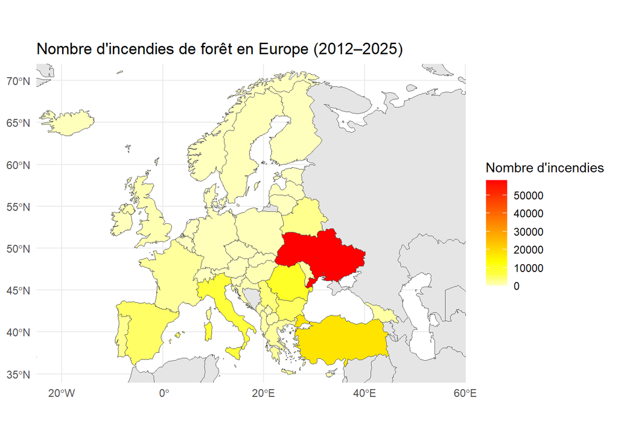

```r
library(readr)
library(dplyr)
library(ggplot2)
library(sf)
library(rnaturalearth)
library(rnaturalearthdata)
df <- read_csv("../Data/annual-number-of-fires.csv")
df_filtre <- df %>% filter(Year >= 2012 & Year <= 2025)
resume_total <- df_filtre %>%
  group_by(Entity) %>%
  summarise(total = sum(`Annual number of fires`, na.rm = TRUE)) %>%
  arrange(desc(total))

pays_europe <- c(
  "Albania", "Andorra", "Armenia", "Austria", "Azerbaijan", "Belarus", "Belgium", "Bosnia and Herzegovina",
  "Bulgaria", "Croatia", "Cyprus", "Czechia", "Denmark", "Estonia", "Finland", "France", "Georgia",
  "Germany", "Greece", "Hungary", "Iceland", "Ireland", "Italy", "Kazakhstan", "Kosovo", "Latvia", "Liechtenstein",
  "Lithuania", "Luxembourg", "Malta", "Moldova", "Monaco", "Montenegro", "Netherlands", "North Macedonia",
  "Norway", "Poland", "Portugal", "Romania", "Russia", "San Marino", "Serbia", "Slovakia", "Slovenia", "Spain",
  "Sweden", "Switzerland", "Turkey", "Ukraine", "United Kingdom", "Vatican"
)

df_europe <- resume_total %>% filter(Entity %in% pays_europe)

europe_map <- ne_countries(scale = "medium", returnclass = "sf")
europe_map <- europe_map %>%
  left_join(df_europe, by = c("name" = "Entity"))

ggplot(data = europe_map) +
  geom_sf(aes(fill = total)) +
  scale_fill_gradientn(colors = rev(heat.colors(10)), na.value = "gray90") +
  labs(
    title = "Nombre d'incendies de forêt en Europe (2012–2025)",
    fill = "Nombre d'incendies"
  ) +
  coord_sf(xlim = c(-25, 60), ylim = c(34, 72), expand = FALSE) +  # Zoom sur l’Europe
  theme_minimal()
```

Cette analyse se penche sur les incendies à travers l’Europe sur une période de 13 ans.

Il est important de noter qu’elle ne se limite pas seulement aux pays méditerranéens, mais couvre également tous les pays situés sur le continent européen.

Nous allons effectuer une analyse informatique suivie d’une analyse statistique.

##### 5.3.6.1 Analyse Informatique

D’abord, nous chargeons les bibliothèques nécessaires pour créer notre carte.

- **readr** Il s’agit d’une bibliothèque utilisée pour une lecture efficace des fichiers de données sous forme de tableau.
- **dplyr** C’est une librairie principalement utilisée pour la manipulation et le traitement des données.
- **ggplot2** C’est une bibliothèque qui va nous assister dans l’élaboration des graphiques basés sur la **Grammaire des Graphiques** de **Wilkinson**, facilitant ainsi la construction et la visualisation de graphiques complexes par superposition de couches.
- **sf** Il s’agit d’une bibliothèque utilisée pour traiter des données géospatiales vectorielles conformément aux normes internationales.
- **rnaturalearth** et **rnaturalearthdata** Il s’agit de deux ensembles qui nous donneront un accès direct aux données géographiques du projet Natural Earth, une source réputée pour ses données géographiques libres de haute qualité.

Suite à cela, nous entamons la phase d’importation et de filtrage des données en employant un chemin relatif pour accéder à notre fichier.

Nous faisons appel à la méthode prédéfinie **read_csv()** pour la lecture de ce dernier et mettons en œuvre un filtrage temporel via une prédiction logique au moyen de la fonction **filter()**.

Ensuite, nous procédons à l’étape d’agrégation et de tri. Nous utilisons une stratégie d’agrégation bien établie nommée **split-apply-combine**.

Dans cette démarche, nous divisons les données par pays en employant la méthode préétablie **group_by()**, puis nous mettons en œuvre une fonction d’agrégation via le biais de la méthode **summarise** avec l’utilisation de **sum**.

Enfin, nous combinons et classons les résultats grâce à la méthode **arrange**.  
Nous utilisons l’option **na.rm=TRUE** pour démontrer une gestion appropriée des valeurs absentes, aspect essentiel pour la robustesse de l’analyse.

Ensuite, on entre dans la phase de **filtrage géographique**, où un vecteur de pays explicite est mis en place plutôt qu’une détection automatique.

Cela nous assure un contrôle précis sur le champ géographique de l’analyse.

L’opérateur **%in%** offre un filtrage vectorisé performant qui nous aide à éviter les boucles explicites.

Par la suite, nous passons à l’étape de **l’intégration géospatiale**.

Pour ce faire, nous exploitons l’obtention de données géospatiales standardisées grâce à **ne_countries()**, qui permet de récupérer des objets vectoriels.

Ensuite, nous utilisons **scale=“medium”** afin d’équilibrer précision et performance dans le but de régler la résolution.

Après cela, on effectue une jointure relationnelle en utilisant un **left_join**, afin d’associer les données attributaires et géométriques.

Nous employons ensuite l’association explicite **c(“name” = “Entity”)** pour harmoniser les identifiants.

Il est important de noter que le choix du **left_join** plutôt que de l’**inner_join** est crucial, car il nous permettra de maintenir tous les pays sur la carte, même ceux dépourvus de données.

Ensuite, nous entamons la phase de construction du graphique en employant la méthode prédéfinie **ggplot** qui s’appuie sur le paradigme de la **grammaire des graphiques**.

Nous superposons les couches grâce à l’approche additive en utilisant l’opérateur **+**.

De plus, nous attribuons des valeurs aux propriétés visuelles via **aes()**, ce qui implique un mappage esthétique.

Par ailleurs, nous gérons les valeurs manquantes à l’aide du paramètre **na.value** pour les pays dépourvus de données.

Pour améliorer la présentation, nous utilisons la fonction **coord_sf()** pour définir l’aire d’intérêt et nous appliquons une optimisation visuelle en employant la méthode **theme_minimal()** afin de diminuer le désordre visuel.

##### 5.3.6.1 Analyse Statistique

Les feux de forêt, devenus depuis de nombreuses années une problématique environnementale de premier plan à l’échelle mondiale.

Dans le cadre de l’Europe, la conjonction du changement climatique, de l’augmentation de l’urbanisation et de la déforestation a accru tant les occurrences que la sévérité de ces incendies.

Cette recherche se base sur une carte représentant le nombre de feux de forêt comptabilisés de 2012 à 2025 dans plusieurs pays d’Europe.

Ce travail d’analyse vise à déchiffrer les inégalités géographiques, à identifier les raisons possibles et à en évaluer les conséquences, tout en mettant l’accent sur les défis majeurs liés à la prévention et à la gestion durable des forêts.

La période considérée va de 2012 à 2025, offrant ainsi une perspective à la fois rétrospective et prospective.

Ainsi, les pays sont classés en fonction de la fréquence des incendies de forêt observés :

Des pays du Sud de l’Europe tels que l’Espagne, la Grèce et l’Italie sont signalés en jaune-orange, témoignant de quelques milliers d’incendies.

En revanche, les pays de l’Europe centrale, de l’ouest et du nord comme l’Allemagne, la France, la Pologne, les nations scandinaves et le Royaume-Uni affichent des nuances très claires qui symbolisent une activité incendiaire faible (moins de 5 000).

La caractéristique la plus marquante de cette carte est la vivacité des couleurs en Ukraine, qui se distingue de façon incomparable.

**Cela suscite plusieurs suppositions fascinantes :**

L’Ukraine est parsemée de vastes forêts mixtes et de steppes, regorgeant de combustible qui pourrait s’enflammer lors d’une sécheresse prolongée.

Depuis 2014, l’instabilité géopolitique a pu provoquer une détérioration de la gestion environnementale dans certaines régions, demeurées sans surveillance appropriée et soumises à des incendies plus ardus à contrôler.

L’augmentation des températures, l’occurrence de sécheresses estivales et parfois de vents forts sont exacerbées par le changement climatique, qui intensifie les dangers naturels.

Située à la frontière de l’Europe et de l’Asie, la Turquie est particulièrement exposée aux incendies en raison de son climat méditerranéen sec pendant les mois d’été.

Par ailleurs, l’extension de l’urbanisation et de l’agriculture augmente le danger pour les êtres humains.

Des nations telles que l’Espagne, l’Italie et la Grèce connaissent régulièrement des incendies chaque été, même si quelques-uns attirent particulièrement l’attention.

Néanmoins, grâce à la surveillance par satellite, des plans d’action rapide et l’engagement des communautés dans la prévention, leur gestion des risques a connu une amélioration.

Cela pourrait justifier leurs statistiques moins élevées qu’en Ukraine ou en Turquie, malgré des conditions météorologiques favorables à l’incendie.

L’Europe de l’Ouest et du Nord paraît assez protégée, grâce à un climat plus humide qui entrave la diffusion naturelle, ainsi qu’à des stratégies forestières strictes telles que l’entretien des sous-bois et la gestion soutenable des forêts.

La représentation du nombre d’incendies forestiers en Europe de 2012 à 2025 met en lumière des écarts saisissants.

Bien que l’Ukraine et la Turquie semblent être les plus affectées, d’autres zones, historiquement touchées comme la Méditerranée occidentale, paraissent avoir mieux contrôlé le phénomène.

Cette recherche souligne la complexité des facteurs, entre environnement naturel, conditions climatiques et actions humaines.

Elle met également l’accent sur l’importance d’une gestion proactive, durable et collaborative des forêts en Europe.

Face à l’aggravation du changement climatique, la faculté des pays à prévoir, éviter et gérer ces désastres naturels façonnera en grande mesure le futur environnemental du continent.

## 6. Ressources

### 6.1 Ressources sur la Partie Informative

Jean-Luc CARTAULT, CLAIR, B., & KAPP, D. (2025, January 29). INCENDIES : Le phénomène physique. Encyclopædia Universalis. https://www.universalis.fr/encyclopedie/incendies/2-le-phenomene-physique/

Contributeurs aux projets Wikimedia. (2004, July 23). feu violent et destructeur. Wikipedia.org; Fondation Wikimedia, Inc. https://fr.wikipedia.org/wiki/Incendie

Risque incendie : causes, conséquences et moyens de lutte. (2021). Preventica.com. https://www.preventica.com/magazine/dossiers/prevention-du-risque-incendie-comment-garantir-la-securite-des-personnes-et-des-biens-11032021/risque-incendie-causes-consequences-et-moyens-de-lutte

### 6.2 Ressources sur la Partie Informatique

Cours et Tutoriels sur le Langage SQL. (2025). SQL. https://sql.sh/

Python Software Foundation. (2019). 3.7.3 Documentation. Python.org. https://docs.python.org/3/

Bien démarrer avec la documentation GitHub - Documentation GitHub. (2025). GitHub Docs. https://docs.github.com/fr/get-started

Qu’est-ce qu’une base de données ? Définition et fonctionnement. (2021, July 26). Hubspot.fr. https://blog.hubspot.fr/marketing/base-de-donnees

### 6.3 Ressources sur la Partie Statistique

Dérobert, N. (2025). Paramètres statistiques - Position et dispersion. Commentprogresser.com. https://commentprogresser.com/statistique-parametre-statistiques-moyenne-mediane-etendue-ecart-type.html

EFFIS - Welcome to EFFIS. (2015). Europa.eu. https://effis.jrc.ec.europa.eu/

Fire Weather Index | Copernicus. (n.d.). Climate.copernicus.eu. https://climate.copernicus.eu/fire-weather-index

Eurostat. (2022). Eurostat. Europa.eu. https://ec.europa.eu/eurostat

France’s unprecedented summer of wildfires, in maps and graphs. (2022, August 25). Le Monde.fr. https://www.lemonde.fr/en/les-decodeurs/article/2022/08/25/fires-in-france-maps-and-graphs-to-visualize-an-unprecedented-summer_5994672_8.html

https://www.climatechangepost.com/france/forest-fires/

The EU 2022 wildfire season was the second worst on record. (2023, April 20). Joint-Research-Centre.ec.europa.eu. https://joint-research-centre.ec.europa.eu/jrc-news-and-updates/eu-2022-wildfire-season-was-second-worst-record-2023-05-02_en

Spain: wildfire area burned 2022. (n.d.). Statista. https://www.statista.com/statistics/1265354/area-burned-by-wildfire-in-spain/

Ministère de l’Intérieur. (2022). 2022. Http://Www.interieur.gouv.fr/Publications/Statistiques/Securite-Civile/2022. https://www.interieur.gouv.fr/Publications/Statistiques/Securite-civile/2022

https://www.vigilfuoco.it/chi-siamo/le-statistiche/annuari-delle-statistiche-ufficiali-del-corpo-nationale-dei-vigili-del-fuoco

https://www.fundacionmapfre.org/publications/todas/estudio-victimas-incendios-en-espana/

Fire-related deaths by region Spain 2022. (n.d.). Statista. https://www.statista.com/statistics/980503/number-of-fire-related-deaths-by-region-spain/